# PADP8120_Lab10: Multiple Regression

# Regression Planes

Last week, we examined bivariate regressions in part by fitting the regression line to a scatter plot of x and y values. Obviously, we can’t do exactly the same thing with multiple regression, because you might have any number of different x variables (i.e., $x_1$,$x_2$, $x_3$… $x_k$). To make things concrete, we will talk about the relationship between education, father’s education, and income using data from the GSS:

$income_i ~ fatherseducation_i + education_i + \epsilon_i$

The code below reads in the data and cleans a few thigns up.

```r
suppressPackageStartupMessages(library(dplyr))
load("input/gss_2010_training.RData")
gss.training <- tbl_df(gss.training)
gss <- select(gss.training, income06_n, educ, maeduc, paeduc) %>%
  filter(!is.na(income06_n), !is.na(educ), !is.na(maeduc), !is.na(paeduc))
# NOTE: DROPPING MISSING DATA LIKE THIS CAN BE DANGEROUS
gss <- dplyr::rename(gss, income = income06_n)
```

One way to look at these data would be to plot each combination of variables against one another. There’s a nice package called `GGally` that has an easy built in function to make this type of plot:

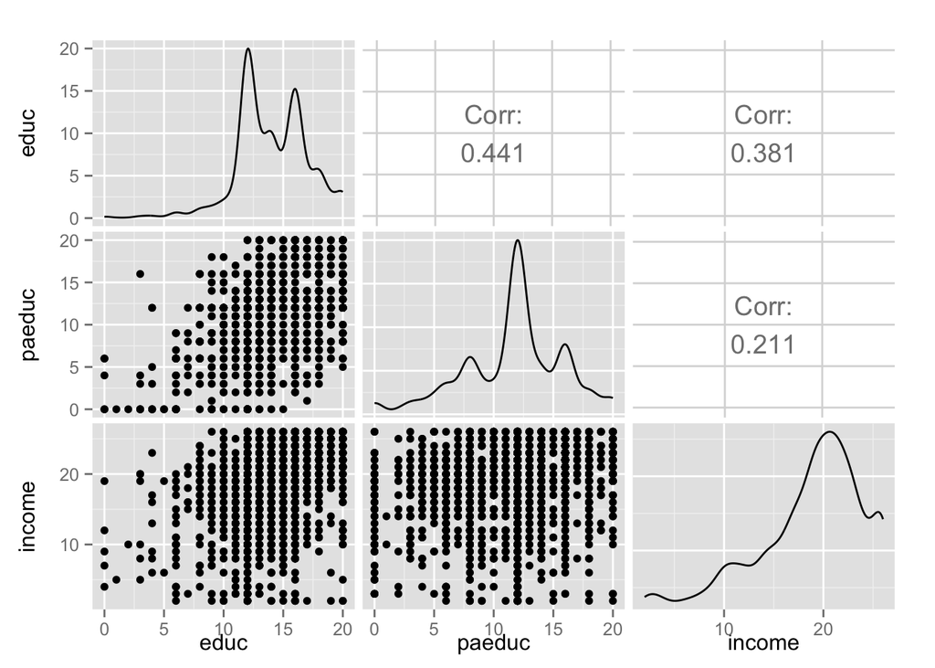

```r
suppressPackageStartupMessages(library(GGally))
pm <- ggpairs(select(gss, educ, paeduc, income))
pm
```

Another way to think about the relationship amongst multiple variables is in terms of more than 2 dimensions (don’t think beyond 3 dimensions though, you don’t want to hurt yourself!). Load the `scatterplot3d` package…

```r
library(scatterplot3d)
```

And then specify a three-dimensional plot using all three variables:

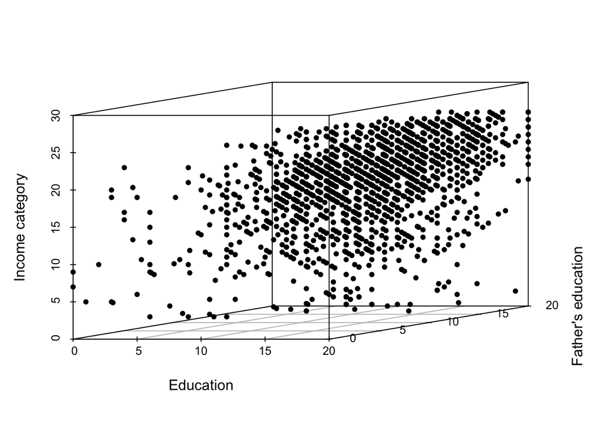

```r
scatterplot3d(x=gss$educ, y=gss$paeduc, z=gss$income,
              xlab="Education", ylab="Father's education",
              zlab="Income category", pch=20, angle=20)
```

You can angle the plot to get a better look…

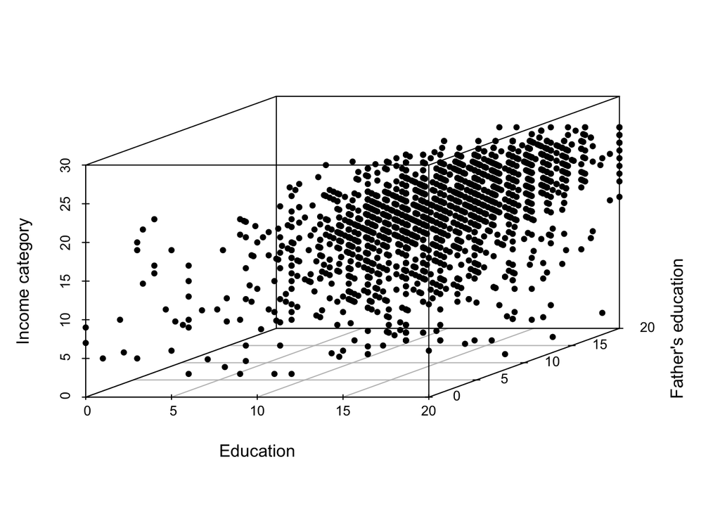

```r
scatterplot3d(x=gss$educ, y=gss$paeduc, z=gss$income,
              xlab="Education", ylab="Father's education",
              zlab="Income category", pch=20, angle=40)
```

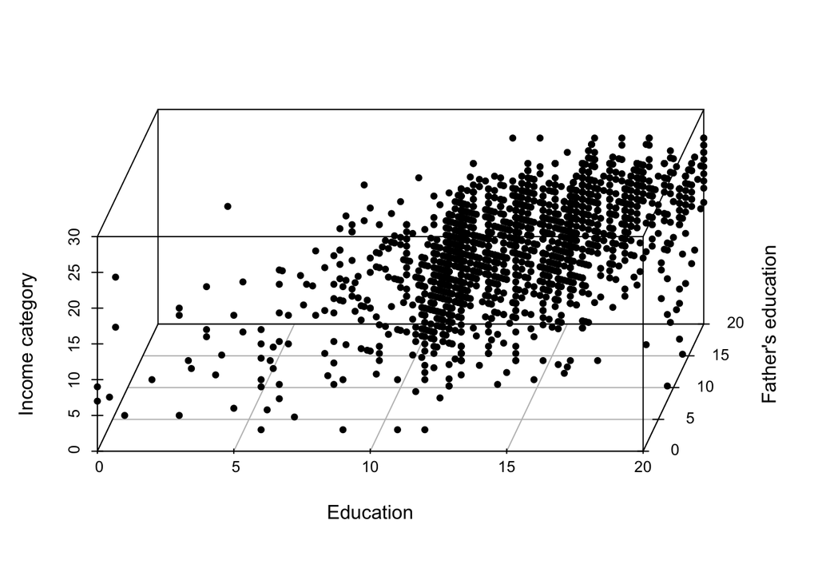

```r
scatterplot3d(x=gss$educ, y=gss$paeduc, z=gss$income,
              xlab="Education", ylab="Father's education",
              zlab="Income category", pch=20, angle=80)
```

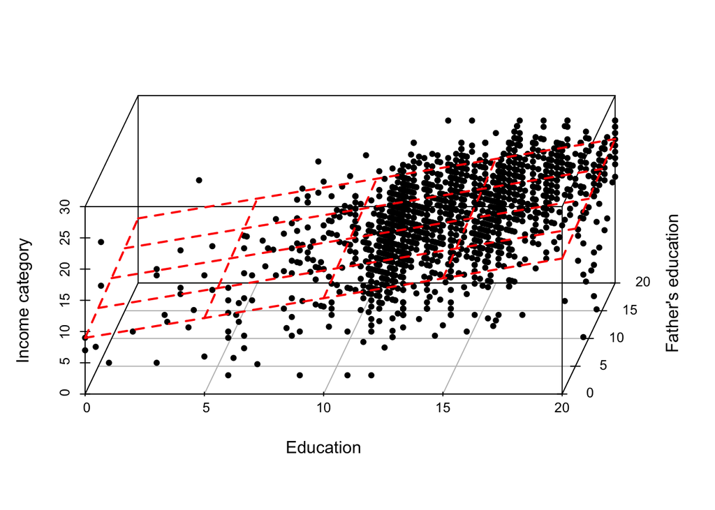

```r
s3d <- scatterplot3d(x=gss$educ, y=gss$paeduc, z=gss$income,
              xlab="Education", ylab="Father's education",
              zlab="Income category", pch=20, angle=80)
my.lm <- lm(gss$income ~ gss$educ + gss$paeduc)
s3d$plane3d(my.lm,col='red',lwd=2)
```

Again, we can change up the angle to get a different perspective…

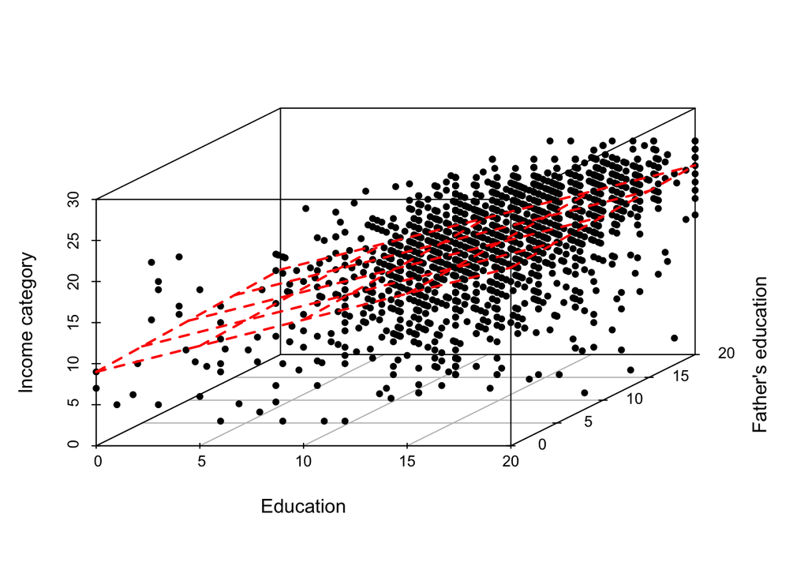

```r
s3d <- scatterplot3d(x=gss$educ, y=gss$paeduc, z=gss$income,
              xlab="Education", ylab="Father's education",
              zlab="Income category", pch=20, angle=50)
my.lm <- lm(gss$income ~ gss$educ + gss$paeduc)
s3d$plane3d(my.lm,col='red',lwd=2)
```

Model is: $\widehat{\mbox{income}}_i = \beta_0 + \beta_1 \times \mbox{educ}_i + \beta_2 \times \mbox{paeduc}_i$

Just as with the OLS line for bivariate regression, the regression plane is the plane that minimizes the sum of the squared residuals. The residual is the difference between the predicted income and actual income for each person in the sample.

$\mbox{income}_i = \beta_0 + \beta_1 \times \mbox{educ}_i + \beta_2 \times \mbox{paeduc}_i + \mbox{residual}_i$

$\widehat{\mbox{income}}_i = \beta_0 + \beta_1 \times \mbox{educ}_i + \beta_2 \times \mbox{paeduc}_i$

As with the line, it is well defined that this is the best fit plane to the whole dataset, but why is that what we want?

## Extrapolation and interpolation in multiple regression

Thankfully, prediction with multiple regression is basically the same as prediction in bivariate regression, albeit with more algebra involved. Because there can be many terms involved, you are better off using R’s `predict` function instead of manual calculation.

19. What is the predicted income for someone whose father has 12 years of education and who has 12 years of education? If we just use `predict(my.lm)` R will give you the fitted value for each observation. In order to make a prediction for this new observation, we need to make a new dataframe:

```r
my.lm <- lm(income ~ paeduc + educ, data=gss)
new.observation = data.frame('paeduc' = 12,'educ'=12)
predict.lm(my.lm,newdata = new.observation)
```

```
##        1
## 17.41802
```

20. What is the predicted income for someone whose father has 20 years of education and who has 0 years of education?

# Multicollinearity

### Example: Car seat position

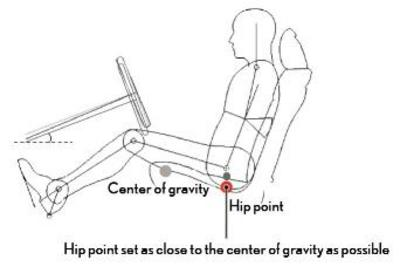

```r
library(faraway)
data(seatpos)
head(seatpos)
```

```
##   Age Weight HtShoes    Ht Seated  Arm Thigh  Leg hipcenter
## 1  46    180   187.2 184.9   95.2 36.1  45.3 41.3  -206.300
## 2  31    175   167.5 165.5   83.8 32.9  36.5 35.9  -178.210
## 3  23    100   153.6 152.2   82.9 26.0  36.6 31.0   -71.673
## 4  19    185   190.3 187.4   97.3 37.4  44.1 41.0  -257.720
## 5  23    159   178.0 174.1   93.9 29.5  40.1 36.9  -173.230
## 6  47    170   178.7 177.0   92.4 36.0  43.2 37.4  -185.150
```

We’ll model hipcenter as a function of all other variables in the dataset…

```r
m1 <- lm(hipcenter ~ ., data = seatpos)
# the dot in the formula notation means 'all other variables'
summary(m1)$coef
```

```
##                 Estimate  Std. Error     t value   Pr(>|t|)
## (Intercept) 436.43212823 166.5716187  2.62008697 0.01384361
## Age           0.77571620   0.5703288  1.36012113 0.18427175
## Weight        0.02631308   0.3309704  0.07950283 0.93717877
## HtShoes      -2.69240774   9.7530351 -0.27605845 0.78446097
## Ht            0.60134458  10.1298739  0.05936348 0.95306980
## Seated        0.53375170   3.7618942  0.14188376 0.88815293
## Arm          -1.32806864   3.9001969 -0.34051323 0.73592450
## Thigh        -1.14311888   2.6600237 -0.42974011 0.67056106
## Leg          -6.43904627   4.7138601 -1.36598163 0.18244531
```

## Assessing multicollinearity

We have several tools at our disposal to assess multicollinearity

- **Pairs plot**: look for strong linear relationships between predictors.
- **Correlation matrix**: calculate the correlation between your predictors using `cor()`.
- **Variance Inflation Factors (VIF)**:

## Pairs plot

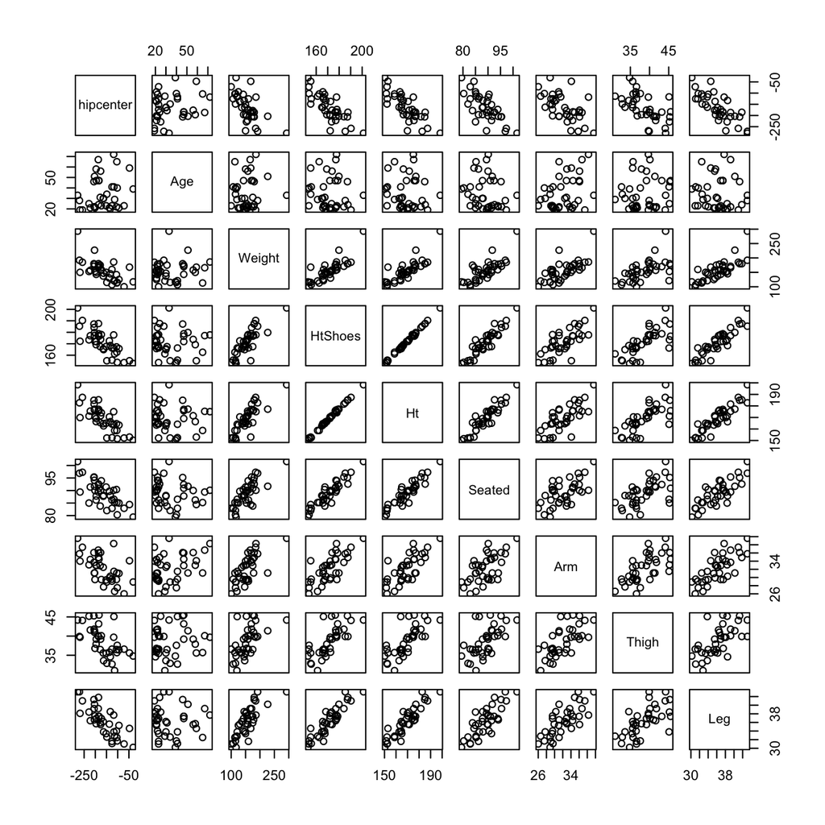

## Correlation matrix

```r
round(cor(seatpos),2)
```

```
##             Age Weight HtShoes    Ht Seated   Arm Thigh   Leg hipcenter
## Age        1.00   0.08   -0.08 -0.09  -0.17  0.36  0.09 -0.04      0.21
## Weight     0.08   1.00    0.83  0.83   0.78  0.70  0.57  0.78     -0.64
## HtShoes   -0.08   0.83    1.00  1.00   0.93  0.75  0.72  0.91     -0.80
## Ht        -0.09   0.83    1.00  1.00   0.93  0.75  0.73  0.91     -0.80
## Seated    -0.17   0.78    0.93  0.93   1.00  0.63  0.61  0.81     -0.73
## Arm        0.36   0.70    0.75  0.75   0.63  1.00  0.67  0.75     -0.59
## Thigh      0.09   0.57    0.72  0.73   0.61  0.67  1.00  0.65     -0.59
## Leg       -0.04   0.78    0.91  0.91   0.81  0.75  0.65  1.00     -0.79
## hipcenter  0.21  -0.64   -0.80 -0.80  -0.73 -0.59 -0.59 -0.79      1.00
```

Correlations above 0.7 will often induce considerable variance in your slopes.

## Variance Inflation Factor

```r
library(car)
m1 <- lm(hipcenter ~ ., data = seatpos)
vif(m1)
```

```
##        Age     Weight    HtShoes         Ht     Seated        Arm
##   1.997931   3.647030 307.429378 333.137832   8.951054   4.496368
##      Thigh        Leg
##   2.762886   6.694291
```

Rule of thumb: VIFs greater than 5 should be addressed.

## Simplifying seatpos

Since most of these variables measure some version of height, we can just use one of them.

```r
m2 <- lm(hipcenter ~ Age + Weight + Ht, data = seatpos)
summary(m2)
```

```
##
## Call:
## lm(formula = hipcenter ~ Age + Weight + Ht, data = seatpos)
##
## Residuals:
##     Min      1Q  Median      3Q     Max
## -91.526 -23.005   2.164  24.950  53.982
##
## Coefficients:
##               Estimate Std. Error t value Pr(>|t|)
## (Intercept) 528.297729 135.312947   3.904 0.000426 ***
## Age           0.519504   0.408039   1.273 0.211593
## Weight        0.004271   0.311720   0.014 0.989149
## Ht           -4.211905   0.999056  -4.216 0.000174 ***
## ---
## Signif. codes:  0 '***' 0.001 '**' 0.01 '*' 0.05 '.' 0.1 ' ' 1
##
## Residual standard error: 36.49 on 34 degrees of freedom
## Multiple R-squared:  0.6562, Adjusted R-squared:  0.6258
## F-statistic: 21.63 on 3 and 34 DF,  p-value: 5.125e-08
```

```r
vif(m2)
```

```
##      Age   Weight       Ht
## 1.093018 3.457681 3.463303
```